# Сетевые технологии

Настройка DHCP, DHCPv6, SLAAC и IPv6 в GNS3

Сейдалиев Тагиетдин Ровшенович

Российский университет дружбы народов, Москва, Россия

29 ноября 2025

# Цель работы

## Основная цель

Получить навыки настройки DHCP, DHCPv6 Stateless и Stateful, SLAAC и IPv6-адресации в виртуальной среде GNS3.

# Выполнение работы

## Топология IPv4

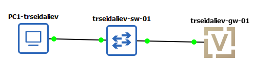

Топология

## Настройка VyOS

- Смена имени хоста и доменного имени
- Создание нового пользователя
- Назначение адреса 10.0.0.1/24
- Настройка DHCP-сервера

[figure not shown]

Консоль

## DHCP-сервер

- Подсеть: **10.0.0.0/24**
- Диапазон: **10.0.0.2–10.0.0.253**
- DNS: **10.0.0.1**
- Домен: **trseidaliev.net**

[figure not shown]

DHCP range

## Клиент PC1

IP: 10.0.0.2/24  
Gateway: 10.0.0.1  
DNS: 10.0.0.1

[figure not shown]

PC1 DHCP

## Проверка работы DHCP

[figure not shown]

PC1 show ip

## Последовательность обмена

- Discover
- Offer
- Request
- ACK

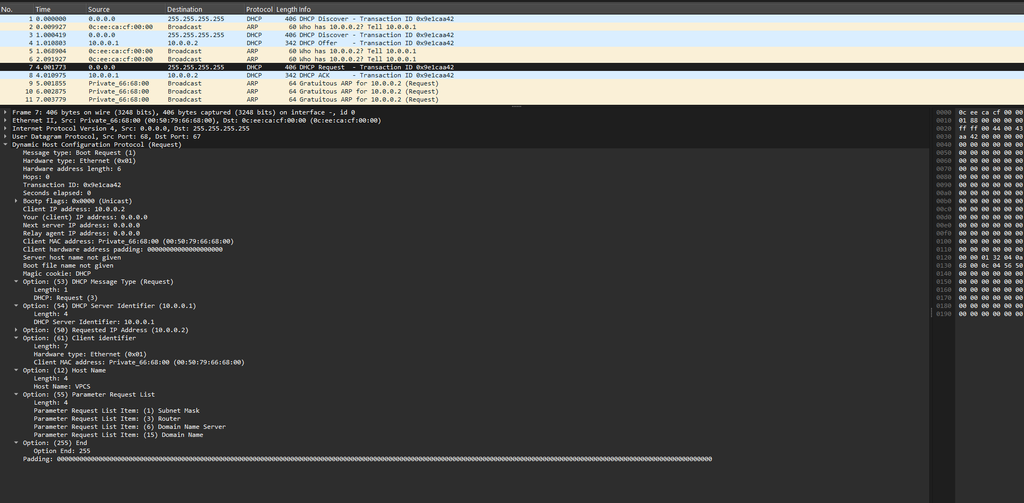

DHCP Wireshark

## Новая расширенная топология

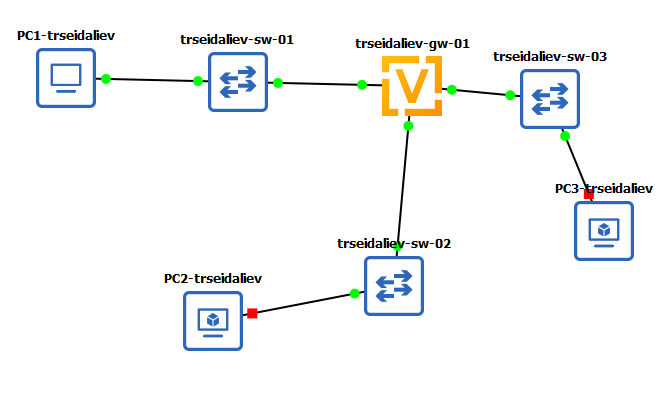

Топология IPv6

## Настройка адресов IPv6

- eth1 → 2000::1/64
- eth2 → 2001::1/64

[figure not shown]

Interfaces IPv6

## Router Advertisement (RA)

- Префикс 2000::/64
- other-config-flag: получение DNS через DHCPv6

[figure not shown]

RA настройка

## DHCPv6 Stateless

Параметры выдаются:  
- DNS: 2000::1  
- Domain-search: trseidaliev.net

[figure not shown]

DHCPv6 Stateless конфигурация

## Клиент PC2 (SLAAC)

Адрес: SLAAC (2000::/64)  
Маршруты добавлены автоматически

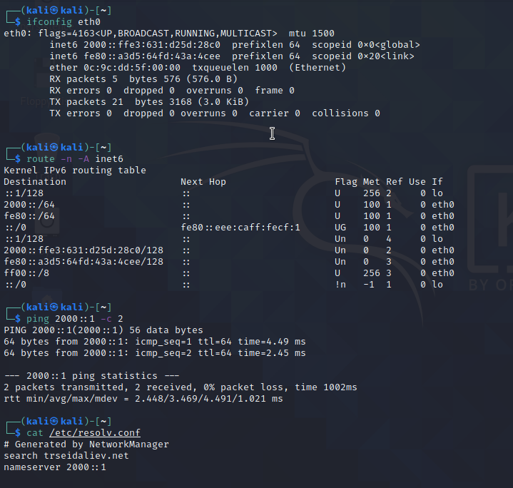

PC2 IPv6 SLAAC

## DHCPv6 Stateless: получение DNS

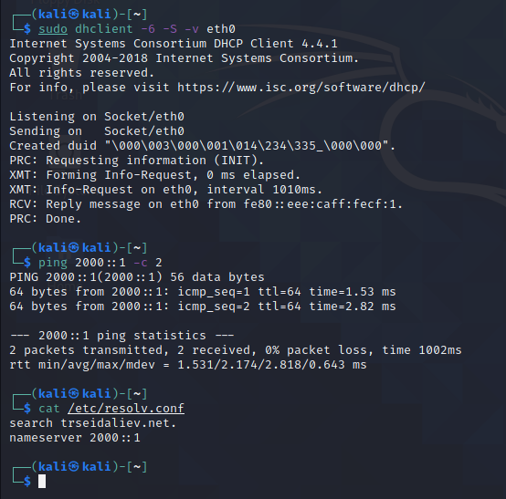

PC2 dhclient -6

## Анализ DHCPv6 Stateless

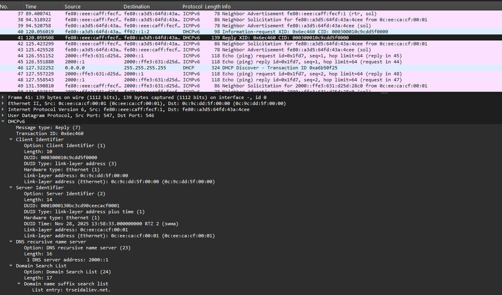

DHCPv6 Stateless Wireshark

## Включение режима Stateful

- RA: managed-flag
- Диапазон адресов: **2001::100 – 2001::199**
- DNS: 2001::1
- Domain-search: trseidaliev.net

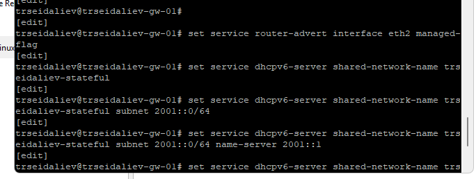

Stateful настройки

## PC3 — до получения адреса

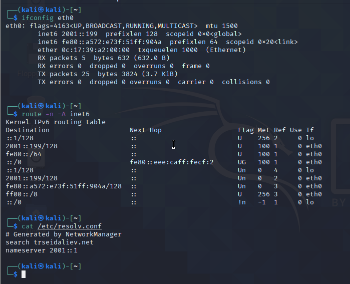

## PC3 — получение адреса DHCPv6 Stateful

[figure not shown]

dhclient Stateful

## PC3 — после получения адреса

Полная конфигурация:  
- IPv6: 2001::198 или 2001::199  
- DNS: 2001::1  
- Пинг до 2001::1 успешен

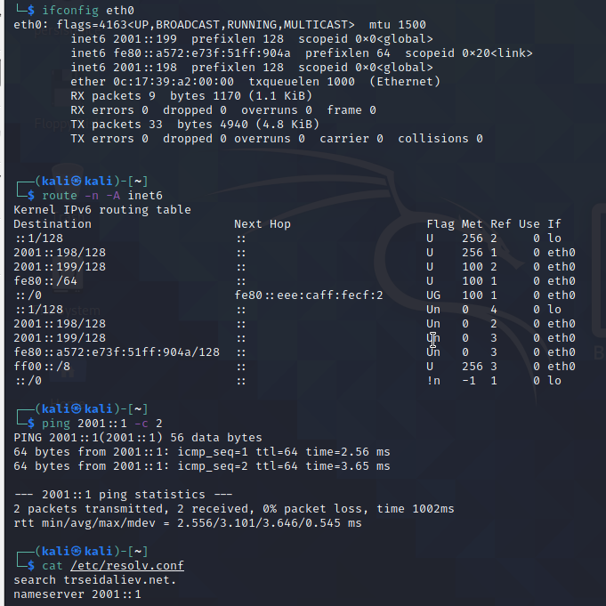

PC3 IPv6 полный

## Просмотр аренд DHCPv6 Stateful

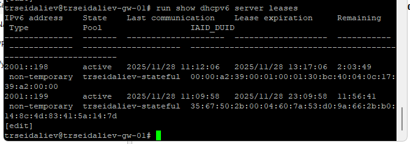

Stateful leases

## Пакеты Solicit, Advertise, Request, Reply

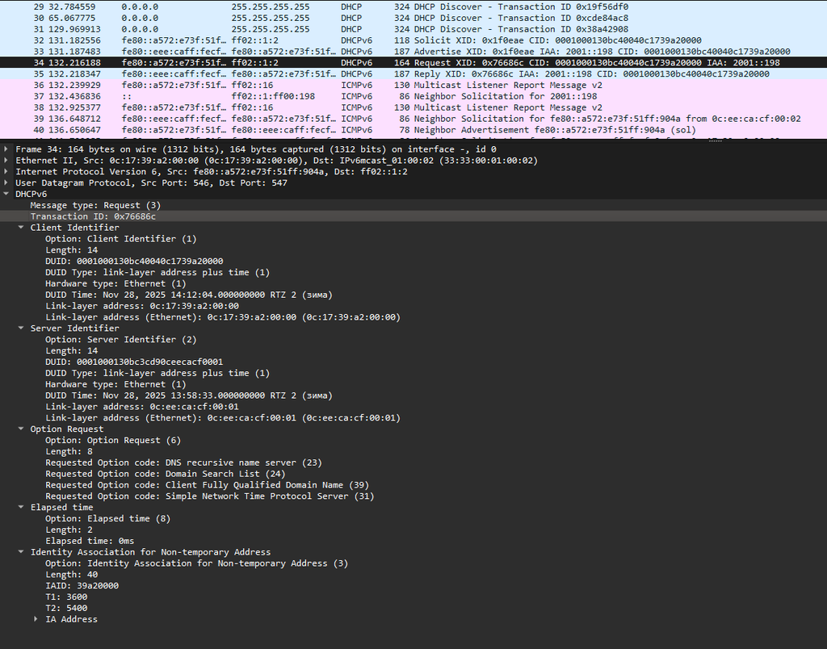

Wireshark DHCPv6 Stateful

# Итоги

## Основные достижения

- Настроен DHCP для IPv4
- Настроены SLAAC, DHCPv6 Stateless и Stateful
- Выполнена полная проверка маршрутизации и связности
- Проанализирован сетевой трафик всех DHCP-механизмов
- Подтверждена корректная работа всех служб распределения адресов